# State Minimum Wage Increases and Low-Wage Employment

A Difference-in-Differences Study with Power, Heterogeneity, and Robustness Analysis

October 01, 2026

## Abstract

This report estimates the employment effect of the 2021 round of state minimum-wage increases on food service and retail employment, and asks whether that effect scales with pre-policy wage exposure. It follows a pre-specified analysis plan (Section 2 of the project proposal): a headline average-effect result (Model A), a primary scientific hypothesis about exposure heterogeneity (Model C’s β₄, explicitly pre-registered as likely underpowered), and a full confirmatory battery – event study, placebo test, COVID-sensitivity spec, wild cluster bootstrap, and model diagnostics – run before either headline number is taken at face value.

**The credibility checks do not support a clean causal interpretation.** The event-study joint tests reject flat pre-trends for both food service and retail. These tests include 2020 and therefore do not establish a purely pre-COVID trend violation. The separate 2019-2020 two-sample test rejects for food service only. Model A is also sensitive to the COVID-severity adjustment. This is reported as a direct limit on how much weight the average-effect estimate can carry, exactly as the proposal’s own design anticipated it might have to be (Section 6.5).

## Related Literature and Contribution

**The disemployment debate.** Card and Krueger’s (1994, *American Economic Review*) comparison of fast-food employment in New Jersey and Pennsylvania around New Jersey’s 1992 minimum-wage increase is the canonical modern minimum-wage DiD design and the direct ancestor of the one used here: a treated state, a neighboring untreated comparison, and a low-wage industry’s employment as the outcome. It found no disemployment effect, against the standard competitive-labor-market prediction. Neumark and Wascher’s contemporaneous and later work (notably their 2000 AER comment on Card-Krueger, and their 2008 MIT Press book *Minimum Wages*) used payroll records instead of the original phone survey and found the opposite, and the resulting back-and-forth established that minimum-wage employment estimates are sensitive to data source, comparison group, and specification in ways that are not obviously resolved by picking a side. That sensitivity is the direct motivation for this report’s own emphasis on credibility checks over a single headline coefficient.

**Refining the comparison group.** Dube, Lester, and Reich (2010, *Review of Economics and Statistics*) addressed the state-pair comparison’s most obvious weakness – that entire states can differ on much more than minimum-wage policy – by comparing contiguous county pairs straddling state borders, finding minimal disemployment effects. This project’s design compares whole states rather than border counties (data availability at the state-industry level is the binding constraint, not a methodological preference), which is precisely why Sections 4 and Appendix C’s checks on whether treated and control states are otherwise comparable carry real weight here: this design is more exposed to the confound Dube-Lester-Reich’s border-pair refinement was built to reduce.

**Exposure and “bite” measures.** Card (1992, *Industrial and Labor Relations Review*) introduced the idea of measuring a labor market’s exposure to a minimum-wage change via the pre-policy share of workers earning near the new floor – a state or industry with more workers close to the floor has more “bite” and should show a larger effect if the competitive model’s prediction holds. Cengiz, Dube, Lindner, and Zipperer (2019, *Quarterly Journal of Economics*) extended this into a full wage-distribution (“bunching”) approach, tracking where in the wage distribution jobs are gained or lost rather than only a net employment count. This report’s exposure variable (Section 2) is a direct descendant of Card’s bite measure, and Model C’s exposure-interaction specification is this study’s primary empirical contribution relative to a plain Card-Krueger-style replication: rather than estimating only an average employment response, it asks whether that response scales with pre-policy exposure, and subjects that relationship to a battery of placebo, permutation, event-study, and specification-curve checks (Section 8) that a replication alone would not need.

**Modern DiD methodology.** A separate literature, mostly unrelated to the disemployment debate itself, has shown that the two-way fixed-effects (TWFE) estimator used throughout this report (Model A, `feols(... | state + quarter)`) can be badly biased when treatment timing is staggered across units and treatment effects are heterogeneous over time – already-treated units can act as implicit “controls” for later-treated ones, and TWFE’s implicit weighting can attach negative weight to some comparisons (Goodman-Bacon 2021, *Journal of Econometrics*; de Chaisemartin and D’Haultfœuille 2020, *American Economic Review*). Callaway and Sant’Anna (2021, *Journal of Econometrics*) and Sun and Abraham (2021, *Journal of Econometrics*) propose heterogeneity-robust estimators for exactly that staggered-timing setting. **This does not mechanically apply to Model A as specified**: every treated state adopts on the same date (2021 Q1), so there is no staggered-timing variation for TWFE to mis-weight in the way Goodman-Bacon decomposes. It is more directly relevant to Model C, where exposure is a continuous rather than binary treatment intensity – a setting closer to the newer literature on DiD with continuous or “dose” treatments (e.g. Callaway, Goodman-Bacon, and Sant’Anna’s work extending difference-in-differences to continuous treatments). Section 6.4 checks the concern those estimators motivate directly, on this data’s own exposure variable, rather than treating a common-timing design being immune to one specific critique as though modern DiD methodology had nothing to add.

**COVID-era labor market disruption.** The 2021 treatment window follows immediately on an unprecedented, highly uneven labor-market shock, and a substantial literature (e.g. Forsythe, Kahn, Kozlowski, and Lange 2020, *Journal of Public Economics*) documents how sharply COVID-19’s labor demand effects varied by sector and geography. That unevenness is the mechanism behind this report’s own COVID-sensitivity specification (Section 4.3) and the exposure-COVID correlation check (Section 8.1) – both ask a version of the same question the broader literature raises at the macro level: whether 2020-2021 outcome differences reflect the policy under study or the pandemic’s own uneven footprint.

**Broader evidence.** Dube’s (2019) review for the UK’s Low Pay Commission surveys the post-2010 empirical minimum-wage literature internationally and finds the median estimated employment effect close to zero with substantial study-to-study variation – consistent with this report’s own conclusion that a single DiD estimate, however carefully checked, does not settle the question on its own.

## Identification Strategy

Before any regression equation, the causal logic this design relies on, stated in plain language:

The diagram below is not a generic textbook DAG – the red backdoor path is this project’s own confounding structure, established empirically rather than assumed (exposure predicting treatment status: Appendix C.2; the exposure-COVID correlation: Section 8.1). It summarizes where this report’s identification concerns actually come from, ahead of the sections that establish each piece directly.

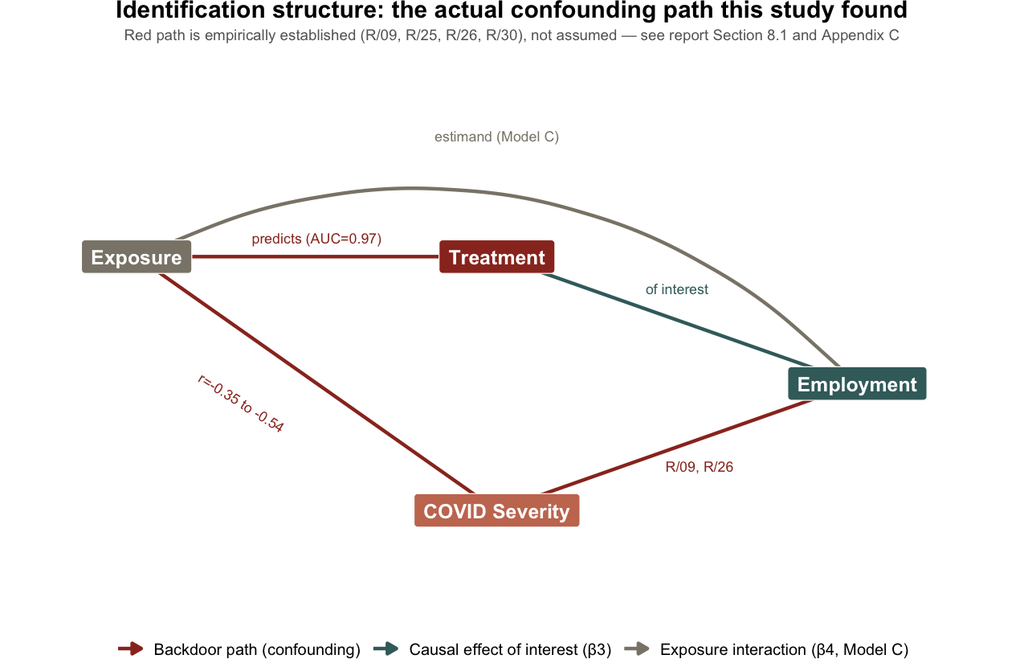

```r
include_graphics(fig("identification_dag.png"))
```

```r
pretrend <- proc("pretrend_joint_test.csv")
```

**Figure 1 – Pre-treatment trends and dynamic treatment effects**

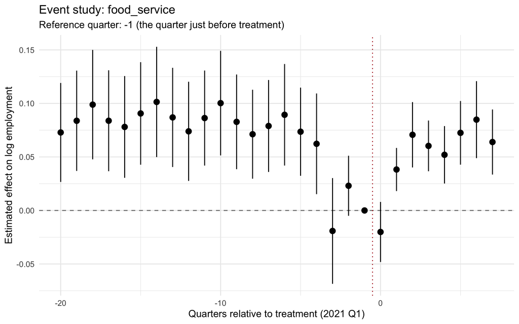

```r
include_graphics(fig("event_study_food_service.png"))
```

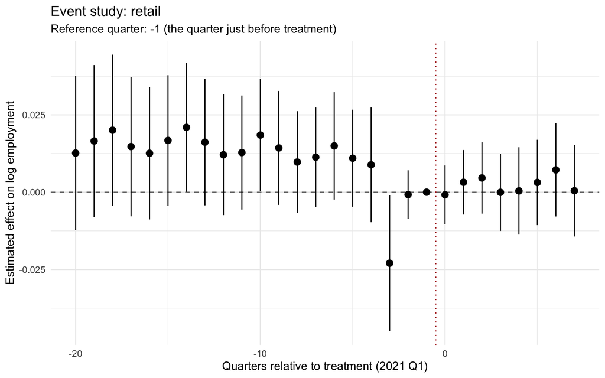

```r
include_graphics(fig("event_study_retail.png"))
```

The formal joint test that every pre-treatment lead equals zero **rejects flat pre-trends for both industries** (food service F = 3.73, p = 1.57^{-4}; retail F = 2.98, p = 0.0014).

**Because the pre-treatment coefficients are not jointly consistent with zero, the parallel-trends assumption is not credible for either outcome. Consequently, the baseline DiD coefficient should not be interpreted as a clean causal estimate.** Section 4 below tests why directly (a COVID-recovery confound explains a substantial share of it), and Section 9’s Limitations section states this plainly rather than qualifying it away. Every result that follows in this report is presented with that finding already on the table, not as a caveat added at the end.

## 1. Data and Treatment Classification

| Source | Role |
| --- | --- |
| FRED (public API) | State-quarter employment (food service, retail), GDP, population, 2015-2022 |
| U.S. DOL minimum wage history (Wayback Machine snapshots) | Treatment classification |
| QCEW Open Data API | Fallback employment series (2 states); wage-ratio validation check |
| CPS-ORG via IPUMS-CPS | Exposure construction (2019-2020 earnings only) |

The design compares **19 treated states** (raised wages effective 1/1/2021) against **26 control states** (source-checked against DOL snapshots from Dec 2020, Feb 2021, and Dec 2021 – confirmed zero minimum-wage movement across all of 2021). A further 5 states raised wages later in 2021 and are excluded from the primary comparison (they aren’t a clean control group for a binary treated indicator).

Two corrections surfaced during data acquisition, both source-verified rather than assumed:

- **Michigan’s 2021 increase never happened.** The draft treatment table had it going $9.65 → $9.87; DOL’s own Feb 2021 snapshot still shows $9.65. Michigan’s automatic adjustment is conditioned on the prior year’s unemployment rate staying under 8.5%; the COVID-era spike tripped that clause and the scheduled step was skipped. Michigan is now classified as a control with no effective 2021 increase date, giving 19 treated and 26 controls. Earlier published estimates used the incorrect treated label; all tables here have been recomputed.
- **The control group itself was missing initially.** The proposal names the 20 treated and 5 excluded states explicitly but never lists the actual “no 2021 change” control group its own design requires – without it there’s no DiD to run. All 25 remaining states were source-checked and used.

```r
tt <- readr::read_csv("../data/treatment_classification.csv", show_col_types = FALSE)
tt %>%
  count(group, name = "n_states") %>%
  kable(caption = "State counts by group")
```

State counts by group

| group | n_states |
| --- | --- |
| control | 26 |
| excluded | 5 |
| treated | 19 |

## 2. Exposure Construction

Exposure is the CPS-ORG-weighted share of a state-industry cell’s workers earning within 12.5% of that state’s pre-2021 minimum wage, computed **only** from 2019-2020 earnings so the post-period outcome can’t contaminate the covariate. The proposal states the band as “10-15%” without picking one number and separately flags band width as a source of construction risk (Section 13); 12.5% (the midpoint) is the primary figure used throughout, with 10% and 15% also computed for sensitivity.

Two validation checks, both passing:

```r
dist_check <- proc("exposure_distribution_check.csv")
qcew_check <- proc("qcew_correlation_check.csv")
```

- **Exposure-distribution check**: food service exposure is higher than retail in 49 of 50 states (mean 0.307 vs. 0.196, Wilcoxon p = 9.93e-10) – the two industries genuinely differ in exposure before that difference is used in Model C.
- **QCEW correlation check**: QCEW’s average wage (hourly proxy) over the state minimum wage, correlated against the CPS-ORG exposure share. Both industries show the expected negative relationship (food service r = -0.82, retail r = -0.71) – high-exposure states really do have wages sitting closer to the floor.

## 3. Descriptive Statistics

```r
proc("descriptive_statistics.csv") %>%
  filter(group %in% c("treated", "control")) %>%
  kable(digits = 4, caption = "Pre-period (2019 Q1 -> 2020 Q4) employment trend, by group / industry / increase type")
```

Pre-period (2019 Q1 -> 2020 Q4) employment trend, by group / industry / increase type

| group | industry | increase_type | n | mean_pre_trend | sd_pre_trend |
| --- | --- | --- | --- | --- | --- |
| control | food_service | inflation_adj_paused | 1 | -0.2650 | NA |
| control | food_service | no_change | 25 | -0.1183 | 0.0843 |
| control | retail | inflation_adj_paused | 1 | -0.0143 | NA |
| control | retail | no_change | 25 | 0.0066 | 0.0411 |
| treated | food_service | inflation_adj | 9 | -0.1544 | 0.0814 |
| treated | food_service | legislation | 10 | -0.2286 | 0.0854 |
| treated | retail | inflation_adj | 9 | 0.0143 | 0.0161 |
| treated | retail | legislation | 10 | -0.0207 | 0.0328 |

## 4. Credibility Checks

Per Section 6.5 of the proposal, these are presented and interpreted **before** any DiD coefficient: “the 2021 treatment window follows an extraordinary labor-market shock. This is a central threat to identification… a limit on how much weight the Model A headline number itself can carry if pre-trends look poor.”

### 4.1 Event Study / Parallel Trends

Dynamic treated × quarter-relative-to-treatment effects, state and quarter fixed effects, state-clustered SEs, 2016 Q1-2022 Q4 (the longest window the growth covariates allow). Shown as Figure 1 in the Identification Strategy section above, ahead of any DiD coefficient; repeated here in a testing context rather than re-embedded.

The pattern isn’t a gradual pre-trend drift so much as a roughly stable, non-zero gap between treated and control states across most of the sample, plus one sharp anomalous dip at quarter -3 relative to treatment – **2020 Q2, the COVID employment trough** – most visible in retail.

**Post-build addition: the same dynamic check for β₄.** The event study above only ever covered Model A’s average effect. Model C’s exposure gradient (β₄, Section 5.2) gets the identical treatment: each relative-quarter dummy interacts with `treated x exposure` (continuous) instead of `treated` (binary), so each coefficient is the dynamic exposure gradient at that quarter rather than a dynamic average effect.

```r
pretrend_beta4 <- proc("pretrend_joint_test_beta4.csv")
```

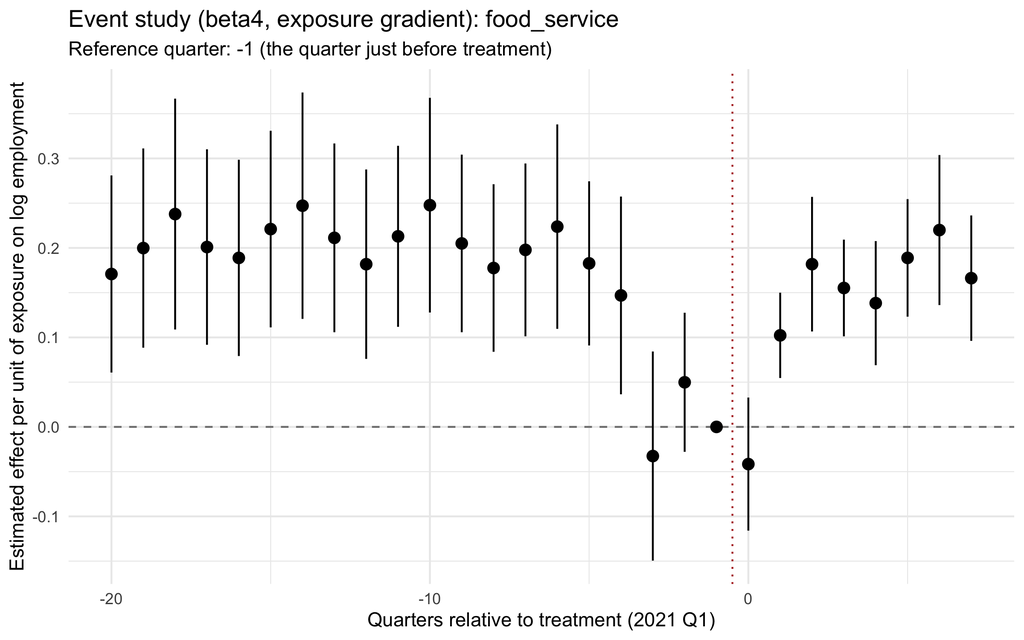

```r
include_graphics(fig("event_study_beta4_food_service.png"))
```

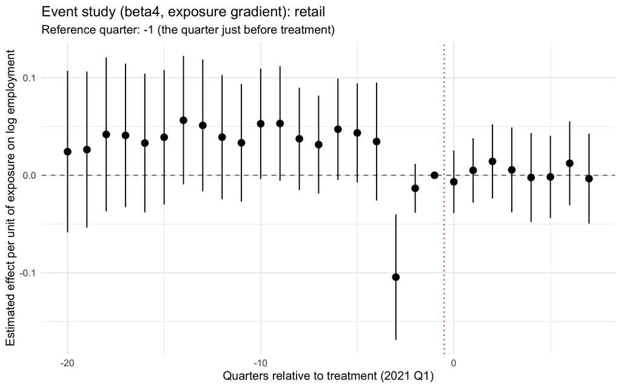

```r
include_graphics(fig("event_study_beta4_retail.png"))
```

### 4.2 Two-Sample t-Test (independent corroboration)

A simpler, STAT-240-level check using a completely different method: compare each state’s raw pre-period (2019 Q1 → 2020 Q4) employment trend between treated and control groups directly, no fixed-effects model involved.

```r
proc("two_sample_ttest_results.csv") %>%
  kable(digits = 4, caption = "Two-sample t-test, pre-period trend: treated vs. control")
```

Two-sample t-test, pre-period trend: treated vs. control

| industry | mean_treated | mean_control | t_statistic | df | p_value | ci_low | ci_high |
| --- | --- | --- | --- | --- | --- | --- | --- |
| food_service | -0.1935 | -0.1239 | 2.5973 | 38.3765 | 0.0133 | 0.0154 | 0.1238 |
| retail | -0.0041 | 0.0058 | 0.9247 | 42.8372 | 0.3603 | -0.0117 | 0.0315 |

Food service shows a real, significant difference: treated states’ pre-period employment trend was already more negative than control states’ *before* treatment started (see the p-value in the table). This independently confirms the event study’s pre-trend violation with unrelated methodology – not a new problem, the same one caught twice.

### 4.3 COVID-Sensitivity Specification

Adds `covid_severity x post` – each state-industry’s log employment change from 2019 Q4 to the 2020 Q2 trough, interacted with the post indicator, since a bare state-constant term would be fully absorbed by the state fixed effect – to Model A and Model C.

```r
covid <- proc("covid_sensitivity_results.csv")
covid %>% kable(digits = 4, caption = "Baseline vs. COVID-sensitivity spec")
```

Baseline vs. COVID-sensitivity spec

| industry | model_a_treated_post_baseline | model_a_treated_post_covid_spec | model_c_beta4_baseline | model_c_beta4_covid_spec |
| --- | --- | --- | --- | --- |
| food_service | -0.0195 | 0.0005 | 0.1425 | 0.0467 |
| retail | -0.0090 | 0.0038 | -0.0061 | 0.1084 |

`covid_severity x post` is highly significant in every specification (p < 10⁻⁸). Once included, Model A’s `treated_post` shrinks toward zero (food service: -0.0195 → 5^{-4}) and Model C’s β₄ shifts substantially, even flipping sign for retail (-0.0061 → 0.1084). Differential COVID recovery explains a real share of what the baseline specification below picks up.

**Post-build addition: does exposure itself predict COVID severity?** Section 8.1 finds that high- and low-exposure states already differed on outcome trends before 2021, across four complementary checks, without identifying a mechanism. This checks the obvious candidate directly: correlate each state’s pre-2021 exposure share with its own COVID severity (same definition as above), restricted to the same treated+control sample every confirmatory model uses.

```r
exp_covid <- proc("exposure_covid_correlation.csv")
exp_covid %>% kable(digits = 4, caption = "Correlation: pre-2021 exposure share vs. COVID severity")
```

Correlation: pre-2021 exposure share vs. COVID severity

| industry | correlation | p_value | n_states |
| --- | --- | --- | --- |
| food_service | -0.3525 | 0.0175 | 45 |
| retail | -0.5383 | 0.0001 | 45 |

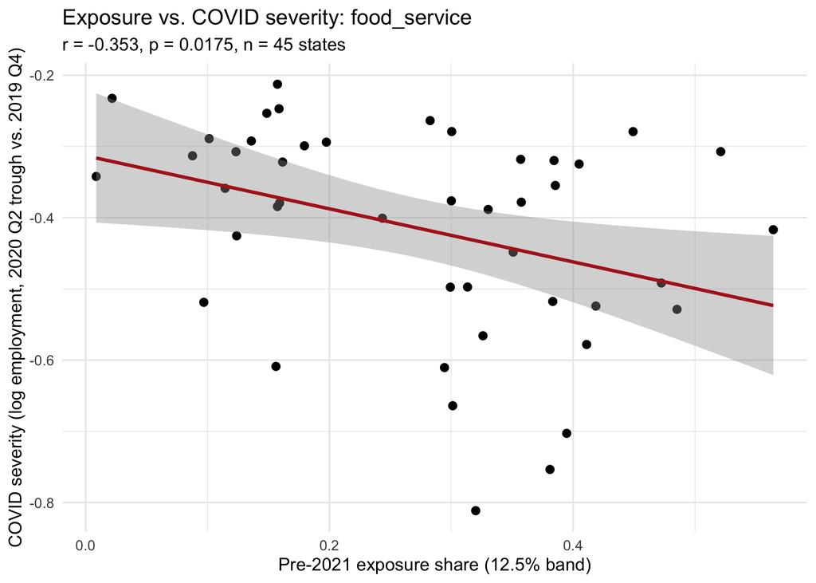

```r
include_graphics(fig("exposure_covid_correlation_food_service.png"))
```

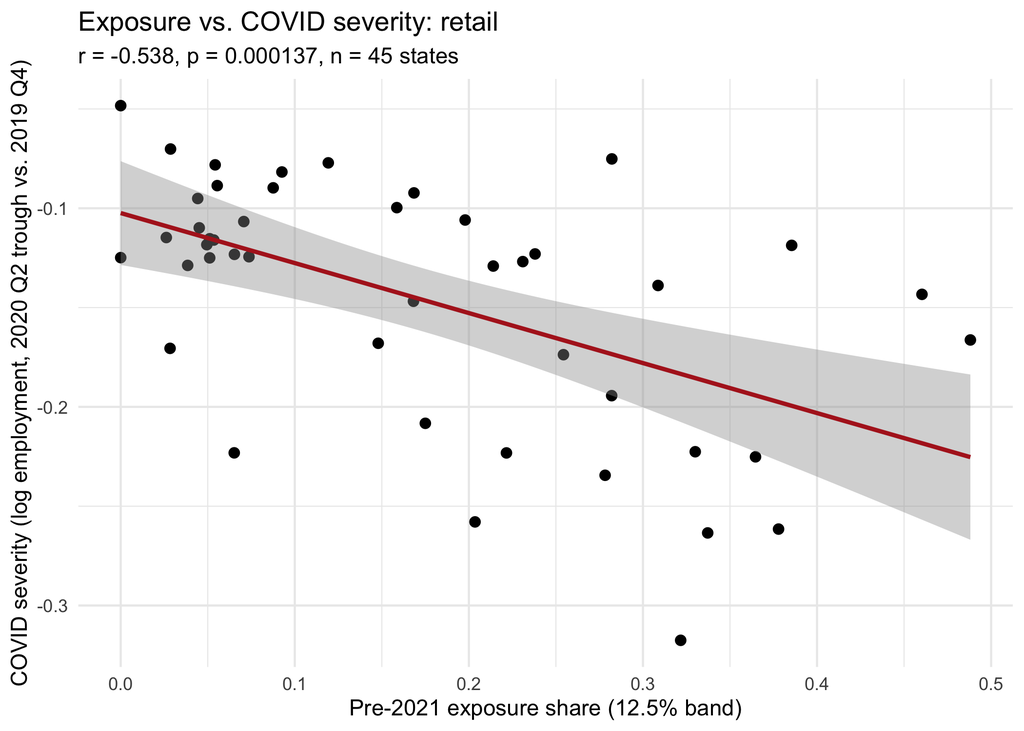

```r
include_graphics(fig("exposure_covid_correlation_retail.png"))
```

Both correlations are negative and statistically significant (food service r = -0.353, p = 0.0175; retail r = -0.538, p = 1.37^{-4}): states with more pre-2021 exposure were hit *harder* by COVID, not just differently. This is a real, plausible candidate mechanism for the Section 8.1 finding – but a candidate mechanism only counts once it’s actually tested, not just proposed.

**Does controlling for it resolve the placebo failure?** The direct test: add `covid_severity x post` (this section’s own COVID-sensitivity covariate) to the placebo-date Model C specification (Section 4.4) and see whether the spurious placebo β₄ shrinks toward zero.

```r
ccp <- proc("covid_controlled_placebo_results.csv")
ccp %>% kable(digits = 4, caption = "Placebo beta4, with and without controlling for covid_severity x post")
```

Placebo beta4, with and without controlling for covid_severity x post

| industry | baseline_beta4 | baseline_beta4_p | covid_controlled_beta4 | covid_controlled_beta4_p | pct_shrinkage |
| --- | --- | --- | --- | --- | --- |
| food_service | 0.1061 | 0.0002 | 0.0970 | 0.0003 | 8.5265 |
| retail | 0.0657 | 0.0170 | 0.0734 | 0.0142 | -11.6446 |

It largely doesn’t. Food service’s placebo β₄ shrinks by only 8.5% and stays highly significant (p = 3.25^{-4}); retail’s actually grows slightly rather than shrinking. **The honest conclusion is narrower than the correlation alone would suggest**: pre-2021 exposure does predict COVID severity, but that specific mechanism, controlled for directly, does not explain away the placebo failure. Something about high-exposure states’ pre-2021 employment trends is systematically different from low-exposure states’ for reasons this design doesn’t fully capture – COVID severity is one contributing, correlated factor, not the whole explanation. The Section 8.1 conclusion (β₄ confounded by a pre-existing association) stands on its own regardless of which underlying variable ultimately explains it.

### 4.4 Placebo Test

A false treatment date (2018-01-01), restricted to a pre-COVID window (2016-2019) so it can’t just re-detect the confound already found above.

```r
proc("placebo_test_results.csv") %>% kable(digits = 4, caption = "Placebo test, Model A (beta3), false treatment date 2018-01-01")
```

Placebo test, Model A (beta3), false treatment date 2018-01-01

| industry | placebo_date | placebo_treated_post | placebo_se | placebo_p |
| --- | --- | --- | --- | --- |
| food_service | 2018-01-01 | -0.0038 | 0.0051 | 0.4642 |
| retail | 2018-01-01 | -0.0043 | 0.0053 | 0.4207 |

Clean result for the average effect: small, non-significant estimates for both industries. The design doesn’t manufacture a Model A-style effect from nothing when there’s no real policy change to detect – the pre-trend problem above is real and specific to the actual treatment window, not a general flaw in the method.

The same check on Model C’s exposure interaction (β₄, Section 5.2, this report’s primary hypothesis) tells a different story:

```r
proc("placebo_test_beta4_results.csv") %>%
  kable(digits = 4, caption = "Placebo test, Model C (beta4), false treatment date 2018-01-01")
```

Placebo test, Model C (beta4), false treatment date 2018-01-01

| industry | placebo_date | placebo_beta4 | placebo_beta4_se | placebo_beta4_p |
| --- | --- | --- | --- | --- |
| food_service | 2018-01-01 | 0.1061 | 0.0261 | 0.0002 |
| retail | 2018-01-01 | 0.0657 | 0.0265 | 0.0170 |

## 5. Core Confirmatory Results

Given Section 4 above, these are reported with the caveat already attached, not as a clean average effect. All four confirmatory estimates, at a glance, before the specification-by-specification detail:

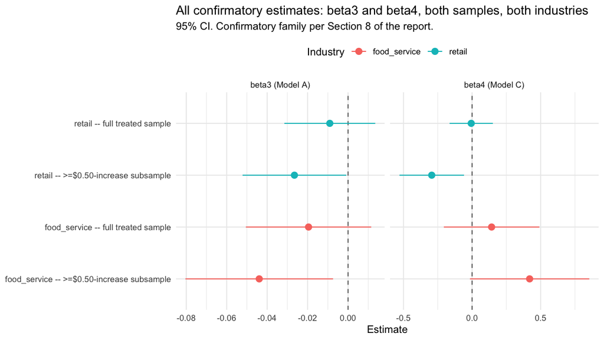

```r
include_graphics(fig("coefficient_forest_plot.png"))
```

### 5.1 Model A – Headline Average Effect (β₃)

Two-way fixed-effects DiD: `log_employment ~ treated_post + gdp_growth + pop_growth | state + quarter`, state-clustered SEs, treated + control states only.

```r
mac <- proc("model_a_c_results.csv")
mac %>%
  select(sample, industry, model_a_treated_post, model_a_se, model_a_p) %>%
  kable(digits = 4, caption = "Model A: treated_post coefficient")
```

Model A: treated_post coefficient

| sample | industry | model_a_treated_post | model_a_se | model_a_p |
| --- | --- | --- | --- | --- |
| full treated sample | food_service | -0.0195 | 0.0158 | 0.2232 |
| full treated sample | retail | -0.0090 | 0.0115 | 0.4351 |
| >=$0.50-increase subsample | food_service | -0.0439 | 0.0186 | 0.0241 |
| >=$0.50-increase subsample | retail | -0.0265 | 0.0131 | 0.0503 |

The estimates remain negative. Only food service in the >=$0.50 subsample is significant at 5%; retail in that subsample is just above 5%. Michigan is no longer counted as a zero-dose treated state. The independent lm cross-check agrees on coefficients; its clustered SEs differ slightly because of finite-sample corrections.

### 5.2 Model C – Exposure Interaction (β₄, primary scientific hypothesis)

```r
mac %>%
  select(sample, industry, model_c_beta4_treated_post_x_exposure, model_c_beta4_se, model_c_beta4_p) %>%
  kable(digits = 4, caption = "Model C: beta4 (treated_post x exposure)")
```

Model C: beta4 (treated_post x exposure)

| sample | industry | model_c_beta4_treated_post_x_exposure | model_c_beta4_se | model_c_beta4_p |
| --- | --- | --- | --- | --- |
| full treated sample | food_service | 0.1425 | 0.1777 | 0.4270 |
| full treated sample | retail | -0.0061 | 0.0805 | 0.9398 |
| >=$0.50-increase subsample | food_service | 0.4196 | 0.2219 | 0.0670 |
| >=$0.50-increase subsample | retail | -0.2940 | 0.1201 | 0.0195 |

Noisy and sign-inconsistent across specifications – positive for food service, negative for retail, significant only in the ≥$0.50 subsample. Section 4.4 of the proposal pre-registers this exact possibility: the design may not reliably distinguish “no gradient” from “real gradient” given the sample size. A noisy β₄ is a valid, expected outcome under that pre-registration, not a failed analysis.

### 5.3 Coefficient Interpretation

Neither coefficient is self-explanatory from the table alone, so spelled out explicitly:

- **Model A (β₃).** The full-sample food-service estimate is -0.0195 – because the outcome is log employment, this corresponds to an approximately 2.0% **lower** employment level for treated states relative to control states after the 2021 increase, holding GDP growth, population growth, and the state/quarter fixed effects constant. It is not a dollar figure, a job count, or a percentage-point change in an employment rate – purely a relative log-scale gap between the two groups.
- **Model C (β₄).** β₄ measures how the *estimated treatment effect itself* changes as a state-industry’s pre-treatment exposure share increases – formally, ∂(treatment effect)/∂(exposure) = β₄. A positive β₄ (food service, this report) means the treatment effect becomes more positive as exposure rises; a negative β₄ (retail) means it becomes more negative. β₄ is not itself an employment effect – it’s the *slope* of the employment effect with respect to exposure, which is why Section 5.4 plots it as a curve rather than a single number.

### 5.4 Marginal Effect of Treatment by Exposure Level

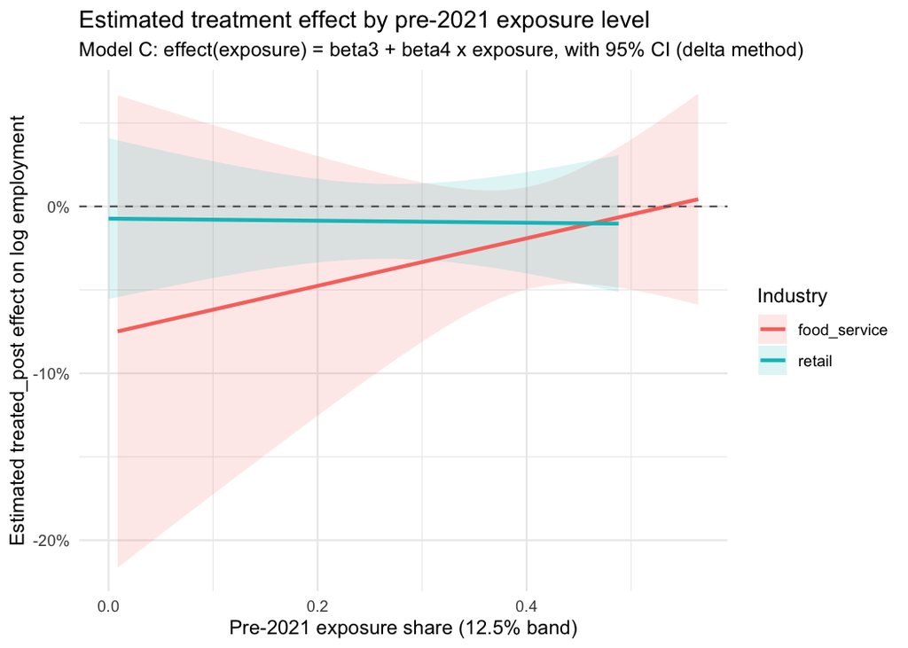

```r
include_graphics(fig("marginal_effects.png"))
```

This is Model C’s practical content: the estimated treatment effect (β₃ + β₄ × exposure) across the actual range of pre-2021 exposure observed, with a 95% confidence band from the model’s clustered variance-covariance matrix (delta method). Food service’s line has a visible upward slope – higher-exposure states show a smaller (less-negative) estimated effect – while retail’s is nearly flat. The band’s width, not just its slope, is the point: it comfortably contains zero across the entire exposure range for both industries, which is the same underpowering conclusion Section 7.5’s formal power analysis reaches by simulation instead of visually.

### 5.5 Exposure Bandwidth Sensitivity

Is β₄ an artifact of the arbitrary 12.5% exposure-band choice? Model C refit at the two alternative bandwidths R/04 already computes (10%, 15%) but never previously used downstream:

```r
bw <- proc("exposure_bandwidth_sensitivity.csv")
bw %>%
  select(bandwidth, industry, beta4, beta4_se, beta4_p) %>%
  kable(digits = 4, caption = "Model C beta4 across exposure bandwidths")
```

Model C beta4 across exposure bandwidths

| bandwidth | industry | beta4 | beta4_se | beta4_p |
| --- | --- | --- | --- | --- |
| 10% | food_service | 0.1916 | 0.1287 | 0.1436 |
| 12.5% | food_service | 0.1425 | 0.1777 | 0.4270 |
| 15% | food_service | 0.0930 | 0.1915 | 0.6298 |
| 10% | retail | -0.0160 | 0.0903 | 0.8605 |
| 12.5% | retail | -0.0061 | 0.0805 | 0.9398 |
| 15% | retail | -0.0190 | 0.0802 | 0.8133 |

The table reports all three bandwidths without selecting a preferred result after observing significance. Check the sign and interval within each industry; differences between industries need not imply instability within an industry.

### 5.6 Leave-One-State-Out Sensitivity

Is Model A’s estimate driven by any single treated state? Section 6.2’s model diagnostics already flag Vermont, New York, and Hawaii as high-leverage (2020 Q2-Q3 observations) – this checks what actually happens to the *coefficient*, not just the leverage diagnostic, refitting Model A once per treated state with that state dropped entirely.

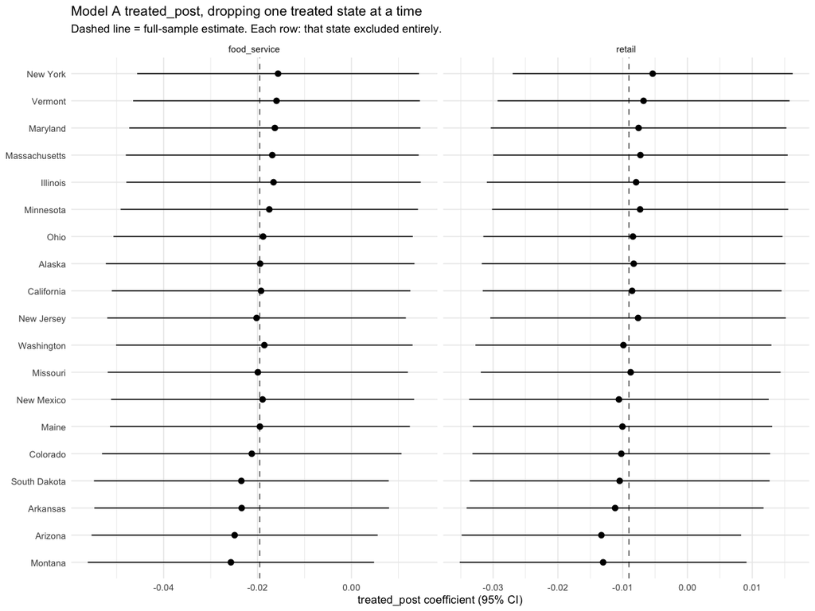

```r
include_graphics(fig("leave_one_out.png"))
```

```r
loo <- proc("leave_one_out_results.csv")
loo %>%
  group_by(industry) %>%
  summarise(min_estimate = min(treated_post), max_estimate = max(treated_post)) %>%
  kable(digits = 4, caption = "Range of treated_post across all 19 single-state exclusions")
```

Range of treated_post across all 19 single-state exclusions

| industry | min_estimate | max_estimate |
| --- | --- | --- |
| food_service | -0.0257 | -0.0156 |
| retail | -0.0133 | -0.0054 |

The estimate stays negative and moves only modestly regardless of which state is dropped, for both industries – reassuring on its own terms, though it doesn’t touch the pre-trend violation or COVID confound already established above.

## 6. Robustness

### 6.1 Wild Cluster Bootstrap for β₃ and β₄

`fwildclusterboot`, the standard package for this, was archived by CRAN in 2024 and doesn’t build on current R, so the Cameron-Gelbach-Miller procedure (999 Rademacher-weight replications on the restricted-model residuals) is implemented directly, for both coefficients – the proposal’s Section 8 only specified β₄, but the same low-cluster-count concern applies equally to β₃.

```r
proc("cluster_bootstrap_results.csv") %>%
  kable(digits = 4, caption = "Wild cluster bootstrap, beta4 (full treated sample)")
```

Wild cluster bootstrap, beta4 (full treated sample)

| industry | beta4 | beta4_se_asymptotic | beta4_t_asymptotic | wild_boot_p_value | wild_boot_ci_low | wild_boot_ci_high |
| --- | --- | --- | --- | --- | --- | --- |
| food_service | 0.1425 | 0.1777 | 0.8018 | 0.4755 | -0.2440 | 0.5339 |
| retail | -0.0061 | 0.0805 | -0.0759 | 0.9369 | -0.1922 | 0.1706 |

```r
proc("cluster_bootstrap_beta3_results.csv") %>%
  kable(digits = 4, caption = "Wild cluster bootstrap, beta3 (full treated sample)")
```

Wild cluster bootstrap, beta3 (full treated sample)

| industry | beta3 | beta3_se_asymptotic | beta3_t_asymptotic | wild_boot_p_value | wild_boot_ci_low | wild_boot_ci_high |
| --- | --- | --- | --- | --- | --- | --- |
| food_service | -0.0195 | 0.0158 | -1.2356 | 0.2152 | -0.0500 | 0.0119 |
| retail | -0.0090 | 0.0115 | -0.7876 | 0.4364 | -0.0333 | 0.0134 |

The tables report bootstrap and asymptotic uncertainty side by side. Neither inference procedure repairs confounding or a failed pre-trend check.

### 6.2 Model Diagnostics

```r
proc("model_diagnostics_summary.csv") %>% kable(digits = 4, caption = "Model A diagnostics summary")
```

Model A diagnostics summary

| industry | n_obs | n_influential | max_cooks_distance | shapiro_p_value |
| --- | --- | --- | --- | --- |
| food_service | 1260 | 77 | 0.0453 | 0 |
| retail | 1260 | 82 | 0.0265 | 0 |

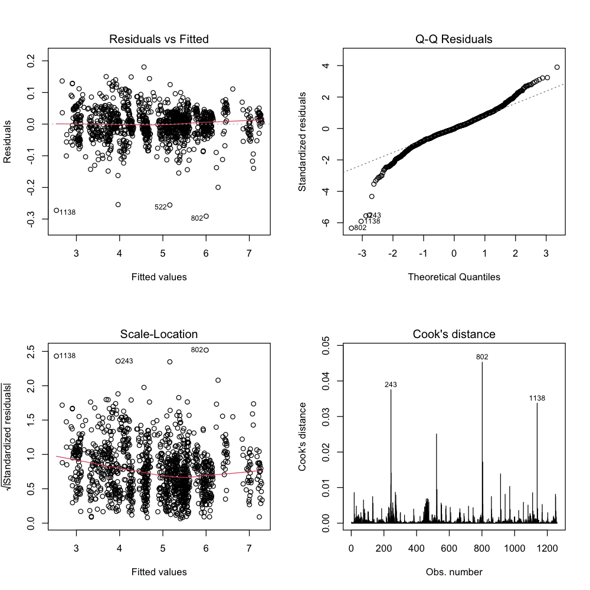

```r
include_graphics(fig("model_a_diagnostics_food_service.png"))
```

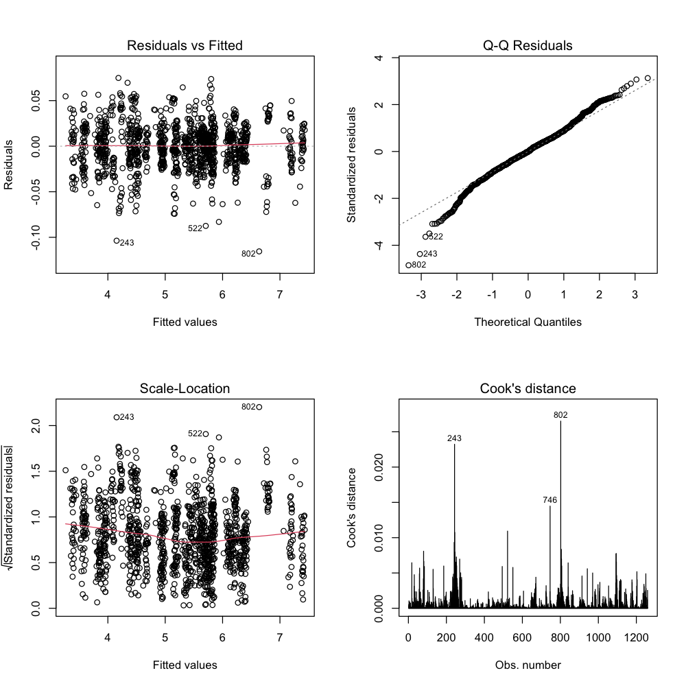

```r
include_graphics(fig("model_a_diagnostics_retail.png"))
```

Residuals are non-normal by Shapiro-Wilk (though that test is hypersensitive with 1,260 observations). More informative: the specific highest-leverage points in both industries are 2020 Q2-Q3 observations – Vermont and New York (Q2 2020), Hawaii (Q3 2020, heavily tourism-dependent) – the same COVID window Section 4 already identified, not a separate data problem. No single observation is extreme by Cook’s distance.

### 6.3 Specification Curve

Sections 5.5 and this report’s sample cut each vary one analytical choice against β₄ in isolation – exposure bandwidth alone, or the full-vs-subsample cut alone. A specification curve varies every combination of both, together with industry, in one view: 3 exposure bands x 2 samples x 2 industries = 12 specifications, all estimating the same β₄ hypothesis.

```r
proc("specification_curve.csv") %>%
  select(bandwidth, sample, industry, beta4, se, p_value, significant) %>%
  arrange(desc(beta4)) %>%
  kable(digits = 4, caption = "beta4 across all 12 specifications")
```

beta4 across all 12 specifications

| bandwidth | sample | industry | beta4 | se | p_value | significant |
| --- | --- | --- | --- | --- | --- | --- |
| 12.5% | >=$0.50 subsample | food_service | 0.4196 | 0.2219 | 0.0670 | FALSE |
| 15% | >=$0.50 subsample | food_service | 0.3932 | 0.2542 | 0.1309 | FALSE |
| 10% | full treated sample | food_service | 0.1916 | 0.1287 | 0.1436 | FALSE |
| 10% | >=$0.50 subsample | food_service | 0.1791 | 0.1626 | 0.2782 | FALSE |
| 12.5% | full treated sample | food_service | 0.1425 | 0.1777 | 0.4270 | FALSE |
| 15% | full treated sample | food_service | 0.0930 | 0.1915 | 0.6298 | FALSE |
| 12.5% | full treated sample | retail | -0.0061 | 0.0805 | 0.9398 | FALSE |
| 10% | full treated sample | retail | -0.0160 | 0.0903 | 0.8605 | FALSE |
| 15% | full treated sample | retail | -0.0190 | 0.0802 | 0.8133 | FALSE |
| 10% | >=$0.50 subsample | retail | -0.1575 | 0.0922 | 0.0963 | FALSE |
| 15% | >=$0.50 subsample | retail | -0.1865 | 0.0844 | 0.0337 | TRUE |
| 12.5% | >=$0.50 subsample | retail | -0.2940 | 0.1201 | 0.0195 | TRUE |

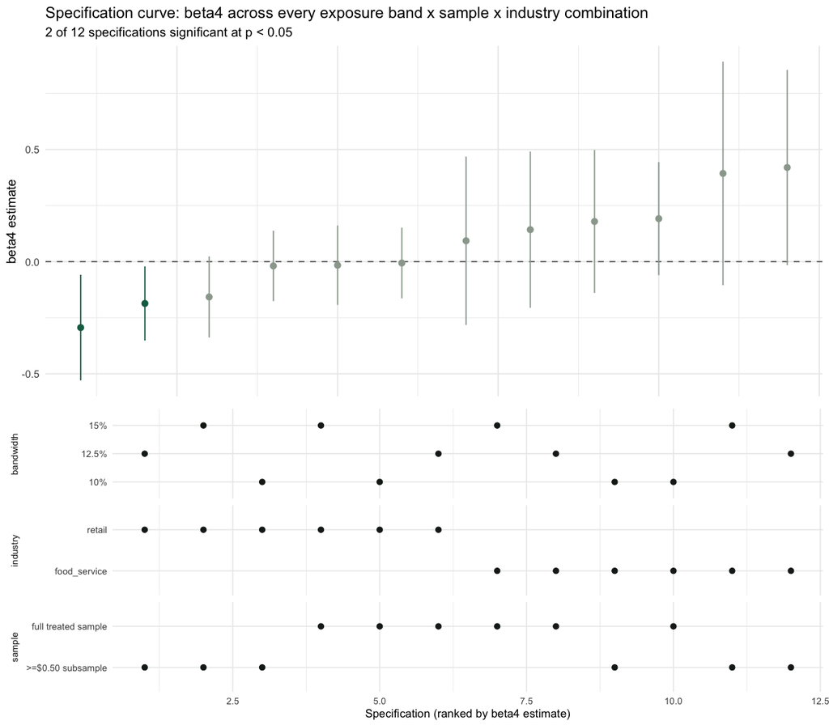

```r
include_graphics(fig("specification_curve.png"))
```

The table reports significance and signs for all 12 specifications. This measures specification sensitivity; it is not by itself a test that an exposure association predates treatment.

### 6.4 Binned Dose-Response Check on Model C’s Linear Interaction

Model C assumes the treatment effect is *linear* in exposure (`treated_post * exposure`). Callaway, Goodman-Bacon, and Sant’Anna’s continuous-treatment DiD work (Section “Related Literature”) warns that imposing linearity on a continuous treatment can average over heterogeneous effects in a way that is hard to interpret, the continuous-treatment analogue of the staggered-binary-adoption negative-weighting problem (Goodman-Bacon 2021). Callaway-Sant’Anna (2021) and Sun-Abraham (2021) themselves target staggered *binary* adoption specifically and don’t mechanically apply to either of this study’s models, so `R/32_modern_did.R` does not fit either estimator. Instead it checks the concern directly: cut exposure into terciles, interact `treated_post` with the tercile dummies instead of the raw continuous value, and see whether the binned coefficients move in a way consistent with Model C’s assumed straight line.

```r
proc("modern_did_results.csv") %>%
  select(industry, model_c_beta4, binned_mid_baseline, binned_high_vs_mid) %>%
  kable(digits = 4, caption = "Model C's linear beta4 vs. the binned (tercile) dose-response")
```

Model C’s linear beta4 vs. the binned (tercile) dose-response

| industry | model_c_beta4 | binned_mid_baseline | binned_high_vs_mid |
| --- | --- | --- | --- |
| food_service | 0.1425 | -0.0223 | 0.0037 |
| retail | -0.0061 | -0.0034 | -0.0078 |

The `binned_low_vs_mid` column (in the full CSV but omitted above) is `NA` for both industries: zero treated states fall in the bottom exposure tercile in this data, so that contrast is unidentified rather than small – a common-support gap, not a null result. This is itself informative: the states that raised their minimum wage in 2021 are not spread evenly across the exposure distribution, which is exactly the kind of imbalance a purely linear specification can obscure. Where the comparison *is* identified (mid vs. high exposure), the binned and linear estimates tell the same qualitative story for both industries – the linear interaction is not papering over a sharply different binned pattern here, though the small per-bin state counts (Section 1) keep every estimate noisy. A clean high-vs-low comparison (dropping the middle tercile entirely, the two exposure groups least like each other) is also in the CSV for the same reason Section 5.6 drops one state at a time: a check that doesn’t depend on every state being used the same way.

## 7. Exploratory Analyses

These inform the picture but don’t validate or override the confirmatory results above (Section 12 of the proposal).

### 7.2 Regional ANOVA – exploratory regional variation in employment growth, not a treatment-effect estimate

This uses the full sample – treated, excluded, *and* control states together – as a general regional comparison, not a causal test of minimum-wage policy. Labeled explicitly here so it isn’t mistaken for another heterogeneity check on the treatment itself: that’s Model C (Section 5.2), the formal test.

```r
proc("regional_anova_results.csv") %>% kable(digits = 4, caption = "One-way ANOVA: log employment change ~ Census region")
```

One-way ANOVA: log employment change ~ Census region

| outcome | f_statistic | df_region | df_residuals | p_value |
| --- | --- | --- | --- | --- |
| log_change_food_service | 5.1044 | 3 | 46 | 0.0039 |
| log_change_retail | 5.6414 | 3 | 46 | 0.0022 |

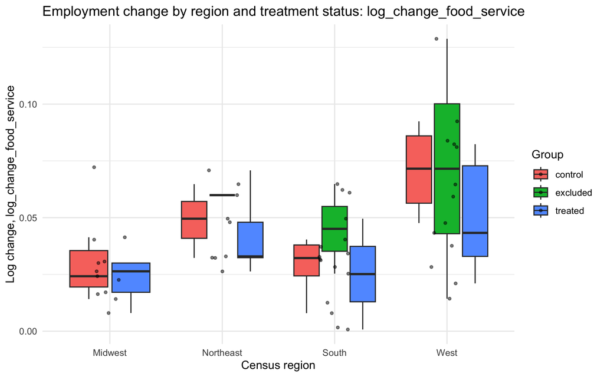

```r
include_graphics(fig("regional_boxplot_log_change_food_service.png"))
```

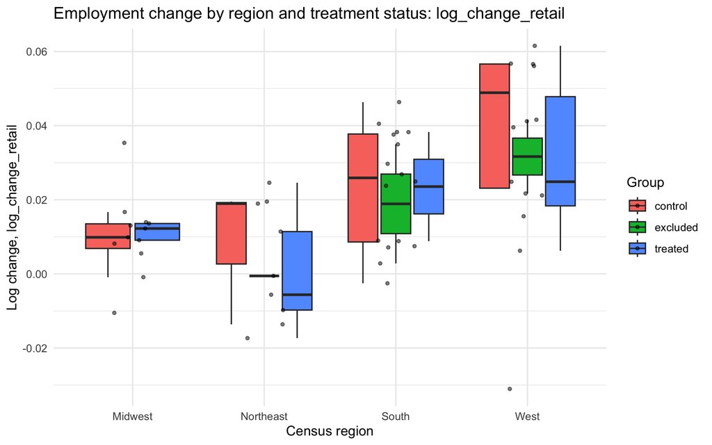

```r
include_graphics(fig("regional_boxplot_log_change_retail.png"))
```

Regions differ significantly in employment growth for both industries (West notably higher than Midwest/South) – real geographic heterogeneity, unrelated to treatment. The exposure interaction in Model C remains the formal heterogeneity test; this is exploratory only.

### 7.3 Monte Carlo Permutation Test

10,000 relabelings of which states are “treated” (state-level, holding n_treated fixed at 19), Model A refit each time.

```r
proc("permutation_test_results.csv") %>% kable(digits = 4, caption = "Permutation test, Model A treated_post")
```

Permutation test, Model A treated_post

| industry | observed_treated_post | null_mean | null_sd | permutation_p_value |
| --- | --- | --- | --- | --- |
| food_service | -0.0195 | -2e-04 | 0.0148 | 0.1907 |
| retail | -0.0090 | -1e-04 | 0.0112 | 0.4301 |

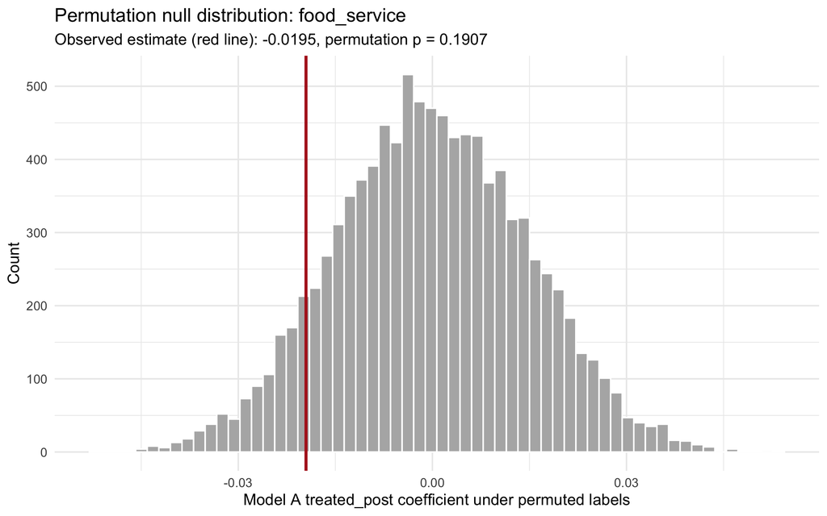

```r
include_graphics(fig("permutation_test_food_service.png"))
```

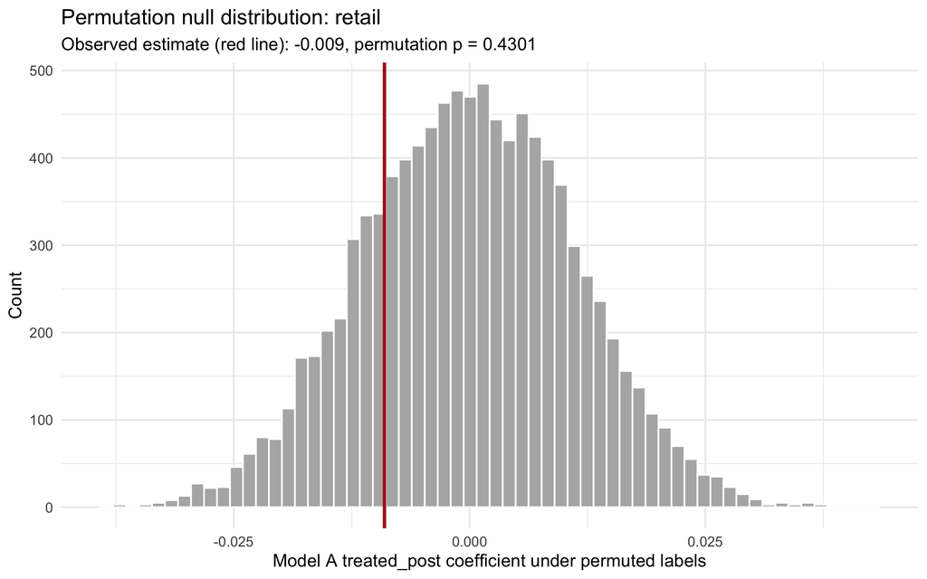

```r
include_graphics(fig("permutation_test_retail.png"))
```

Permutation reference distributions are reported above. Assignment was not randomized, so these are descriptive sensitivity checks.

Post-build addition:** this section originally covered Model A only. The same relabeling exercise applies to Model C’s exposure interaction (β₄, Section 5.2, the primary scientific hypothesis) – each replication keeps every state’s own exposure value fixed and only randomizes which states count as “treated,” the same logic as the Model A version above.

```r
proc("permutation_test_beta4_results.csv") %>%
  kable(digits = 4, caption = "Permutation test, Model C (beta4) treated_post:exposure")
```

Permutation test, Model C (beta4) treated_post:exposure

| industry | observed_beta4 | null_mean | null_sd | permutation_p_value |
| --- | --- | --- | --- | --- |
| food_service | 0.1425 | -0.0867 | 0.0641 | 0.1886 |
| retail | -0.0061 | -0.0766 | 0.0610 | 0.9575 |

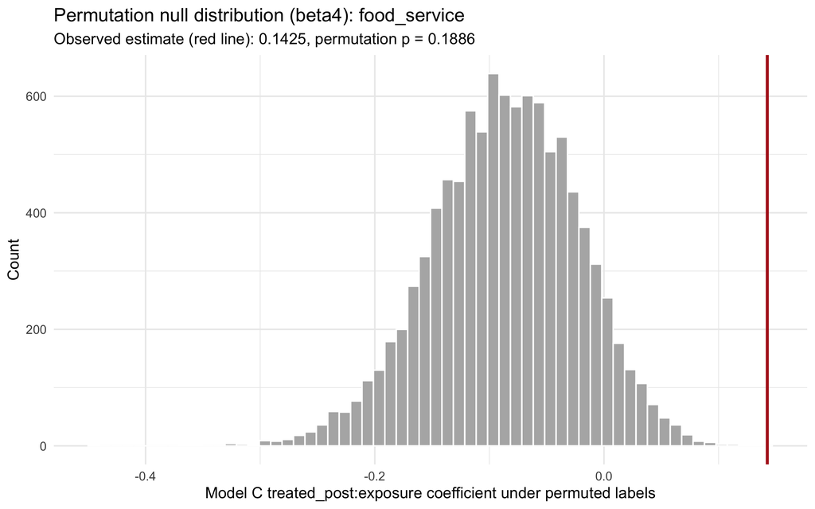

```r
include_graphics(fig("permutation_test_beta4_food_service.png"))
```

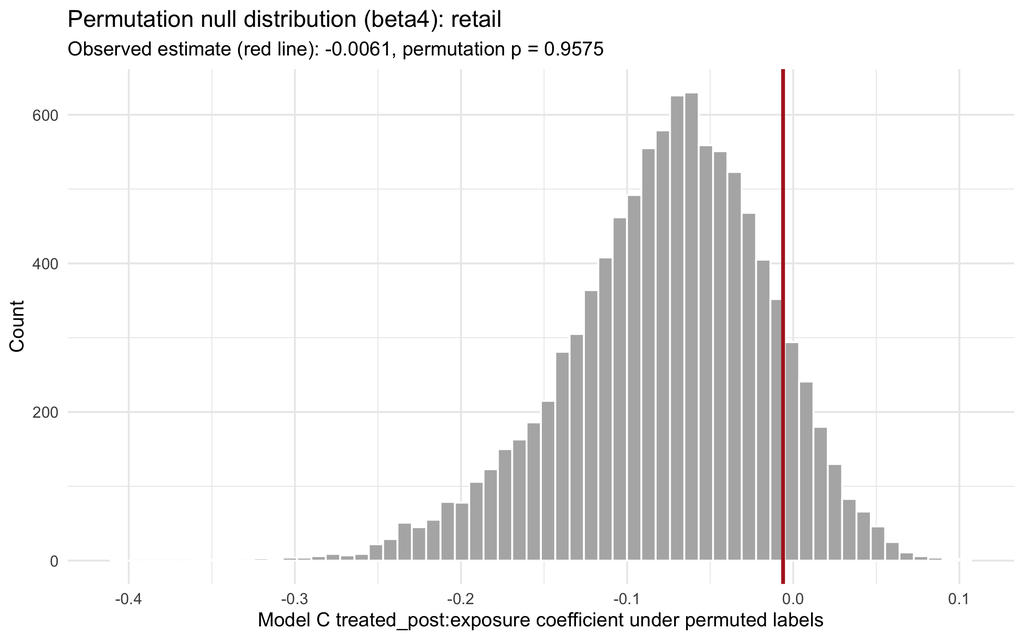

```r
include_graphics(fig("permutation_test_beta4_retail.png"))
```

An off-center permutation distribution can reflect exposure-related structure and model specification. It is not a standalone proof of confounding or an exact randomization test under this observational assignment mechanism.

### 7.4 Power Analysis for β₃ (Model A average effect, added after the original build)

Section 4.4 specifies two power analyses, not one: average-effect power for β₃ at assumed sizes of 0.5%, 1%, 2%, and 3%, reporting the minimum detectable effect (MDE); and a separate heterogeneity-detection power analysis for β₄ (Section 7.5). Both were added after the original 10-day build (`R/16_power_analysis.R`).

```r
proc("power_analysis_beta3_results.csv") %>% kable(digits = 4, caption = "Observed beta3 vs. minimum detectable effect at 80% power, Section 4.4's assumed grid (0.5%-3%)")
```

Observed beta3 vs. minimum detectable effect at 80% power, Section 4.4’s assumed grid (0.5%-3%)

| industry | observed_beta3 | mde_80 |
| --- | --- | --- |
| food_service | -0.0195 | NA |
| retail | -0.0090 | NA |

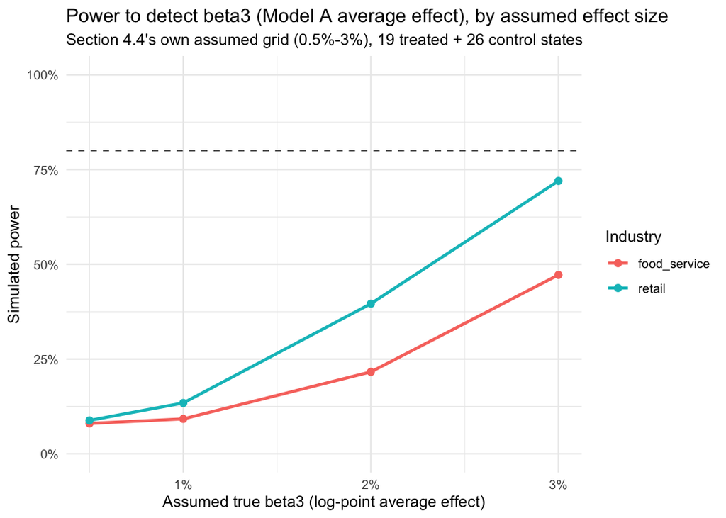

```r
include_graphics(fig("power_analysis_beta3.png"))
```

The table and curve show whether 80% power is reached on the tested 0.5%-3% grid. An NA means it was not reached, not that an MDE was estimated outside that grid. Power depends on this fitted simulation design and does not establish a causal effect.

### 7.5 Power Analysis for β₄ (exposure gradient, added after the original build)

The exposure-gradient hypothesis (β₄) was separately pre-registered as likely underpowered (Section 4.4’s heterogeneity-detection question). The quantitative version – a residual-based Monte Carlo power simulation on the real panel – makes that concrete.

```r
proc("power_analysis_results.csv") %>% kable(digits = 3, caption = "Observed beta4 vs. minimum detectable effect at 80% power")
```

Observed beta4 vs. minimum detectable effect at 80% power

| industry | observed_beta4 | mde_80 |
| --- | --- | --- |
| food_service | 0.143 | 0.50 |
| retail | -0.006 | 0.22 |

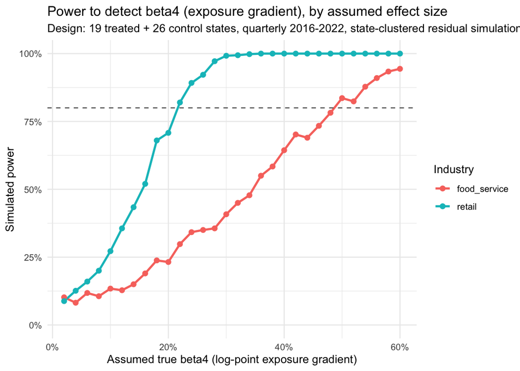

```r
include_graphics(fig("power_analysis.png"))
```

Compare each observed coefficient with its industry’s simulated MDE in the table. The MDE is a design-dependent threshold, not evidence that the observed coefficient is causal or that the true effect is zero.

### 7.6 Exploratory Treatment-Intensity Model

**Exploratory, not confirmatory** – not part of the six-check confirmatory family in Section 8. The dollar size of a state’s increase is not randomly assigned; states that raised wages by $1.00 vs. $0.08 may differ systematically in ways unrelated to the policy itself. With that caveat: does a *larger* increase correspond to a larger employment response, rather than a simple treated/not-treated split?

```r
proc("treatment_intensity_results.csv") %>%
  kable(digits = 4, caption = "Exploratory: log employment ~ (wage increase x post), continuous dollar amount")
```

Exploratory: log employment ~ (wage increase x post), continuous dollar amount

| industry | beta1_wage_increase_post | beta1_se | beta1_p |
| --- | --- | --- | --- |
| food_service | -0.0358 | 0.0172 | 0.0429 |
| retail | -0.0196 | 0.0140 | 0.1689 |

The continuous-intensity results are exploratory and share the identification concerns of Model A/C.

## 8. Multiple Testing and Inferential Hierarchy

Two things are true at once in this report, and they’re not in tension: Model A (Section 5.1, β₃) is the headline result, and β₄ (Section 5.2) is the primary scientific hypothesis. They answer different questions – “is there an average effect” versus “does it vary with exposure” – and one is never substituted for the other. Model A is reported first because it’s the best-powered result (Section 7.4 quantifies exactly how well-powered); β₄ is reported alongside its own power ceiling (Section 7.5) rather than read as a clean null just because it came back noisy.

The **confirmatory family** is small and explicit, fixed before any model was run rather than assembled after seeing results: Model A and Model C for both industries (Sections 5.1, 5.2), the event study (Section 4.1), the exposure-measurement validation (Section 2), both power analyses (Sections 7.4, 7.5), the wild cluster bootstrap (Section 6.1), and the placebo/COVID-sensitivity checks (Sections 4.3, 4.4). This family is what determines the headline claim.

The **regional ANOVA** (Section 7.2), the **SLR/MLR** coursework-closure pieces (Section 7.1), and the **Monte Carlo permutation test** (Section 7.3) are exploratory. For Model A they inform the picture without changing it – the permutation test corroborates β₃’s asymptotic p-value from a distribution-free angle. For β₄, the permutation test’s role is different: its null distribution for food service isn’t centered at zero, which is itself evidence about the exposure measure rather than just a robustness check on the p-value (Section 8.1 below). None of these exploratory pieces validate or overturn the confirmatory family’s result, and none are treated as if they could.

### 8.1 Convergent Evidence Against the Exposure-Gradient Interpretation

Four complementary checks, run for different reasons and living in four different sections, all point the same direction on β₄. Collected in one place rather than left scattered:

```r
proc("beta4_robustness_summary.csv") %>%
  kable(caption = "Four complementary checks on beta4's credibility")
```

Four complementary checks on beta4’s credibility

| check | food_service | retail |
| --- | --- | --- |
| Placebo test (false 2018 date) | p = 0.0002 | p = 0.0170 |
| Permutation test (label reassignment) | p = 0.1886 (null not centered at zero) | p = 0.9575 (null not centered at zero) |
| Specification curve (12 specs) | 0 of 6 significant, positive in 6 of 6 | 2 of 6 significant, negative in 6 of 6 |
| Event study (pre-trend joint test) | p = 0.0002 | p < 0.0001 |

No single one of these is individually damning – a placebo test can fail by chance, a specification curve can look messy without meaning much, one permutation null can drift off-center in a finite sample. What makes this convergent rather than coincidental is that four methodologically unrelated approaches (a false-date comparison, a label-randomization null, an exhaustive grid of analytical choices, and a dynamic quarter-by-quarter decomposition) all land on the same conclusion: high- and low-exposure states differ systematically for reasons that predate the 2021 policy. β₄ is reported throughout this report exactly as designed – honestly, regardless of significance – but it should be read as **inconclusive at best, and confounded by a pre-existing exposure-outcome association at worst**, not as evidence either for or against a real exposure gradient in the employment response.

Naming the confirmatory family also means it can be corrected for formally, not just described narratively. Holm-adjusted p-values across the 4 primary tests (β₃ and β₄, both industries, headline specification):

```r
proc("multiple_testing_correction.csv") %>%
  kable(digits = 4, caption = "Holm-adjusted p-values, confirmatory family")
```

Holm-adjusted p-values, confirmatory family

| coefficient | industry | p_raw | p_holm |
| --- | --- | --- | --- |
| beta3 | food_service | 0.2232 | 0.8927 |
| beta3 | retail | 0.4351 | 1.0000 |
| beta4 | food_service | 0.4270 | 1.0000 |
| beta4 | retail | 0.9398 | 1.0000 |

None of the 4 survive correction at the headline specification – the same conclusion Sections 5 and 7 already reach individually, now stated as a formal joint test rather than four separate uncorrected p-values that happen to agree.

## 10. Conclusion

The corrected analysis assigns Michigan to the 2021 control group. Both industries fail the event-study joint pre-trend test. The separate two-sample trend test rejects for food service only. COVID adjustment changes the estimates, and exposure-gradient placebos remain a concern. These results warrant caution about causal interpretation; a non-significant coefficient does not establish no effect.

## Additional interpretation limits

Treatment is defined by 2021 changes only. Some controls, including Michigan, raised wages in 2022, so a constant treated/control label through 2022 does not isolate all subsequent policy changes. A time-varying policy history is needed before interpreting the comparison as a clean single-adoption experiment.

The treatment-classifier accuracy and AUC below are in-sample fit statistics, not held-out prediction estimates. The DAG is a hypothesized causal structure informed by associations; correlation does not establish its arrow directions.

## Appendix

The three sections below are secondary extensions, not co-equal with Sections 1-10’s causal analysis: a predictive-modeling comparison and two exploratory checks on treatment assignment. They inform how the main results should be read; they do not revise them.

### Appendix A: Machine Learning & Neural Network Extension

Everything above is aimed at a causal question: did the 2021 minimum-wage increases change employment. This section asks a different, narrower question instead – how well can flexible ML methods *predict* quarterly employment growth for a state they never saw during training, versus a plain linear specification? **It is a predictive-accuracy comparison, not a causal claim**, and doesn’t revise anything concluded above.

Two design choices matter for interpreting the numbers below. First, evaluation holds out entire *states*, not rows: a row-level split would let the same state’s quarters appear on both sides, leaking within-state structure the causal models’ clustered SEs already treat as non-independent. Second, the prediction target is employment *growth*, not the level of `log_employment`: the level is dominated by each state’s sheer size (California vs. Wyoming), which none of these features could recover for a state held out entirely – that would make the held-out evaluation unwinnable by construction. Growth is scale-invariant across states and is the quantity a policy could plausibly move.

```r
ml <- proc("ml_comparison_results.csv")
ml %>%
  kable(digits = 4, caption = "Held-out predictive accuracy, by state (R/27_ml_prediction.R, R/28_neural_network.R)")
```

Held-out predictive accuracy, by state (R/27_ml_prediction.R, R/28_neural_network.R)

| model | rmse | r_squared |
| --- | --- | --- |
| linear_baseline | 0.0699 | 0.3940 |
| bagged_trees | 0.0669 | 0.4442 |
| random_forest | 0.0644 | 0.4855 |
| gradient_boosting | 0.0537 | 0.6420 |
| neural_network | 0.0644 | 0.4844 |

Five methods, in increasing order of how much structure they can capture:

- **Linear baseline** – no state or quarter fixed effects (unlike Model A/C above), since a fixed effect can’t generate a prediction for a state it never saw.
- **Bagged trees** – bootstrap-aggregated `rpart` trees, each with one fixed random feature subset for its entire fit (the “random subspace” method).
- **Random forest** (`randomForest` package) – the actual Breiman algorithm: every split, in every tree, re-samples which features are even candidates, not just once per tree.
- **Gradient boosting** (`gbm` package) – a different combination strategy entirely: trees are fit sequentially, each one to the residual error the ensemble so far still has, with the number of trees chosen by 5-fold cross-validation rather than fit until they stop improving on the training data.
- **Neural network** (`nnet`) – a single hidden layer; with ~1,000 training rows and 5 predictors, a deeper architecture would be capacity in search of data it doesn’t have.

Gradient boosting is the strongest predictor of the five, which is a sensible result rather than a foregone one: boosting’s sequential, residual-fitting strategy is genuinely different from bagging and random forests’ independent-trees-then-average strategy, and there’s no a priori guarantee either wins on a given dataset.

An independent Python replication (`python/`) – numpy/pandas for data handling, hand-rolled implementations of the same three tree ensembles plus a PyTorch feedforward network, since this development environment’s `scipy`/scikit-learn install doesn’t import cleanly (see `python/README.md`) – reaches the same qualitative conclusion: gradient boosting outperforms the other tree ensembles and the linear baseline. Full details, and why `BaggedTrees`/`RandomForest`/`GradientBoostedTrees` are three genuinely different implementations rather than the same ensemble under different names, are in `python/README.md` and `python/src/minwage/ml/random_forest.py`.

### Appendix B: Wage Pass-Through

A new research question, not a re-analysis of the one above: did the 2021 increases actually raise **earnings** in low-wage industries, and by how much relative to the dollar size of the mandate? Sections 1-11 all ask whether employment fell; this asks whether the policy did the thing it was actually meant to do.

**Data limitation, found by direct request** (`R/29_wage_passthrough.R`, matching this project’s standing practice of confirming FRED series IDs against live data rather than guessing): BLS/FRED do not publish state-level average hourly earnings at the detailed NAICS-722 (food service) or 44-45 (retail trade) level Sections 1-11 use for employment – every candidate series ID at that resolution 404s. The finest available state-level breakdown is the CES **supersector**: “Leisure and Hospitality” (nests food service, but also accommodation and arts/entertainment/recreation) as the closest proxy for food service, and “Trade, Transportation, and Utilities” (nests retail, but also wholesale trade, transportation, and utilities) as the closest proxy for retail. Both are broader than this study’s employment industries, so this section answers a related but not identical question – not “did retail workers’ wages rise” but “did wages in retail’s broader supersector rise.”

The specification is otherwise identical to Model A (Section 5.1): `build_panel()` and `fit_model_a()` from `R/07` are reused completely unchanged, with the wage-proxy series substituted in as the outcome.

```r
wp <- proc("wage_passthrough_results.csv")
wp %>%
  select(proxy_industry, treated_post_log_coef, se, p_value,
         mandated_dollar_increase, implied_dollar_increase, pass_through_ratio) %>%
  kable(digits = 4, caption = "Wage pass-through: Model A's treated_post on proxy-industry earnings")
```

Wage pass-through: Model A’s treated_post on proxy-industry earnings

| proxy_industry | treated_post_log_coef | se | p_value | mandated_dollar_increase | implied_dollar_increase | pass_through_ratio |
| --- | --- | --- | --- | --- | --- | --- |
| Leisure & Hospitality (food service proxy) | 0.0024 | 0.0096 | 0.8026 | 0.5647 | 0.0396 | 0.0701 |
| Trade, Transportation & Utilities (retail proxy) | 0.0137 | 0.0116 | 0.2414 | 0.5647 | 0.3261 | 0.5774 |

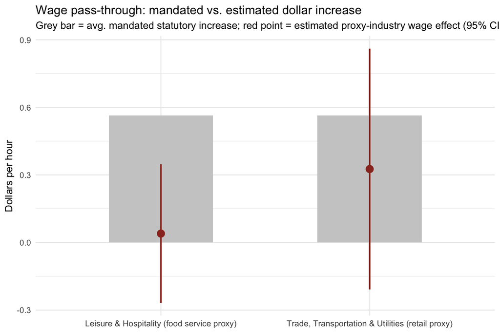

```r
include_graphics(fig("wage_passthrough.png"))
```

Neither estimate is statistically significant, and the food-service proxy’s confidence interval crosses zero. Read alongside this report’s recurring theme (Sections 7.4-7.5’s power analysis, the noisy β₄ throughout), the honest interpretation is “underpowered to detect pass-through at this resolution,” not “pass-through is genuinely these point estimates.” The likeliest reason both point estimates sit well under 100% regardless: the supersector proxies include large numbers of workers (hotel managers, arts/entertainment/recreation staff, wholesale and utilities employees) who were never near the minimum wage to begin with, diluting any real effect on the low-wage workers the policy actually targeted.

### Appendix C: Treatment Assignment: Predictability & Clustering

Exploratory analyses investigating systematic differences in pre-treatment economic structure between treated and comparison states (a chi-square test of independence, logistic regression as a classifier, k-means, PCA). Appendix C.4 states directly why these results, however striking, do not themselves bear on whether the DiD design is valid – read that section before drawing conclusions from C.1-C.3 in isolation.

#### C.1 Is Treatment Independent of Census Region?

```r
tp_results <- proc("treatment_predictability_results.csv")
tp_results %>%
  select(n_states, chisq_statistic, chisq_df, chisq_p_value) %>%
  kable(digits = 4, caption = "Chi-square test: treatment status x Census region")
```

Chi-square test: treatment status x Census region

| n_states | chisq_statistic | chisq_df | chisq_p_value |
| --- | --- | --- | --- |
| 45 | 7.8966 | 3 | 0.0482 |

A chi-square test of independence rejects independence at the 5% level: the South is heavily under-represented among treated states relative to control (Section 7.2’s regional ANOVA already hinted at regional heterogeneity in outcomes; this shows the regional imbalance starts with treatment assignment itself, not just the response to it).

#### C.2 Is Treatment Predictable from Pre-Period Characteristics?

A logistic regression on pre-period (2019-2020) GDP growth, population growth, and food-service exposure – the same variables used elsewhere in this report, not new ones picked to make this check look more dramatic than it is – classifies treated vs. control states at n=45:

```r
tp_results %>%
  select(n_states, logit_accuracy, logit_auc) %>%
  kable(digits = 3, caption = "Logistic regression: treated ~ pre-period growth + exposure")
```

Logistic regression: treated ~ pre-period growth + exposure

| n_states | logit_accuracy | logit_auc |
| --- | --- | --- |
| 45 | 0.867 | 0.966 |

```r
proc("treatment_predictability_coefficients.csv") %>%
  select(term, Estimate, `Std. Error`, `z value`, `Pr(>|z|)`) %>%
  kable(digits = 4, caption = "Logistic regression coefficients")
```

Logistic regression coefficients

| term | Estimate | Std. Error | z value | Pr(>\|z\|) |
| --- | --- | --- | --- | --- |
| (Intercept) | -12.1869 | 4.8708 | -2.5020 | 0.0123 |
| avg_gdp_growth | 13.1667 | 33.8112 | 0.3894 | 0.6970 |
| avg_pop_growth | 28.6614 | 98.2083 | 0.2918 | 0.7704 |
| exposure | 37.2422 | 14.5484 | 2.5599 | 0.0105 |

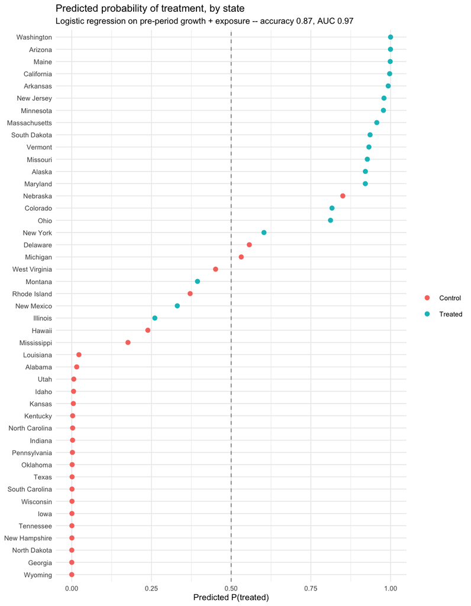

```r
include_graphics(fig("treatment_predictability.png"))
```

These are in-sample accuracy and AUC, not held-out estimates. Section C.4 explains why they do not establish or invalidate parallel trends.

#### C.3 Do States Cluster by Treatment Status?

Unsupervised this time – no label is given to the algorithm. A hand-rolled k-means (k-means++ initialization; see `R/31_state_clustering.R`) on the same pre-period features, standardized, with k chosen from the elbow curve below (gradual, not sharply bent at any one k – k=3 is a judgment call, not a value the curve alone dictates):

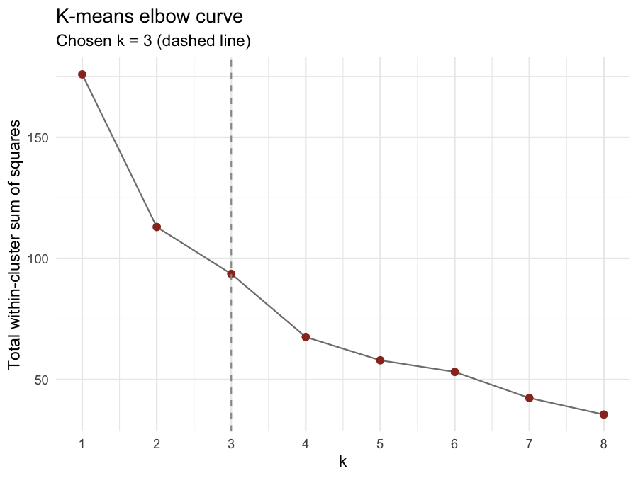

```r
include_graphics(fig("state_clustering_elbow.png"))
```

```r
sc_results <- proc("state_clustering_results.csv")
sc_results %>%
  kable(digits = 4, caption = "k-means (k=3): fit quality and cluster x treatment independence test")
```

k-means (k=3): fit quality and cluster x treatment independence test

| k | wcss | chisq_statistic | chisq_p_value | pc1_variance_explained | pc2_variance_explained |
| --- | --- | --- | --- | --- | --- |
| 3 | 93.6189 | 26.3487 | 0 | 0.5139 | 0.3263 |

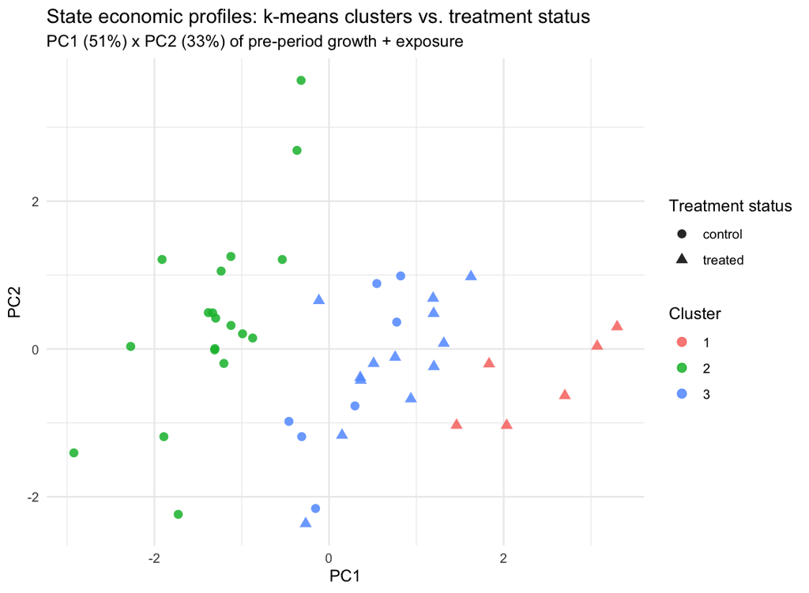

```r
include_graphics(fig("state_clustering_pca.png"))
```

Two of the three clusters are almost entirely pure treated or pure control (see the updated chi-square test above) – states weren’t assigned to clusters by treatment status, yet cluster membership predicts it almost as well as the logistic regression above does. This is exploratory, not a fourth confirmatory test – no cluster-based hypothesis was pre-registered anywhere in the original proposal.

#### C.4 What This Does and Doesn’t Imply for Identification

**This does not, by itself, invalidate the DiD design.** Difference-in- differences does not require random treatment assignment. States choosing to raise their minimum wage for identifiable political or economic reasons is entirely compatible with valid causal identification, *provided* the relevant conditional parallel-trends assumption holds – that is the assumption DiD actually rests on, not “as-if random” assignment. Treatment being this predictable doesn’t do the identification work itself.

*Reproducibility: every number and figure in this report is generated by running `R/01_treatment_classification.R` through `R/31_state_clustering.R` in order, from `min-wage-difference-in-differences-study`’s repo root (`make all` does this end to end). See `README.md` for full reproduction details.*